# PacifichakeMSE

Nis S Jacobsen

April 30, 2020

# Introduction

This is a description of the ‘PacifichakeMSE’ package to run management strategy evaluation of Pacific hake. The package sets up a set of parameters, and runs an operating model in R, and fits an estimation in TMB.  
The package runs on a range of dependencies, most notably TMB, which require a developer version of R. For more information on TMB see https://github.com/kaskr/adcomp

To install the ‘PacifichakeMSE’ package run

```r
devtools::install_github('https://github.com/nissandjac/PacifichakeMSE')
```

Load the dependencies

```r
library(TMB)
library(r4ss)
library(devtools)
library(PacifichakeMSE)
library(dplyr)
library(ggplot2)
library(reshape2)
library(patchwork)
```

# Operating model

First we can initialize the parameters of the operating model using the function ‘load_data_seasons’

```r
df <- load_data_seasons(nseason = 4, # Specifies the number of seasons
                        nspace = 2, # Specifies the number of areas
                        logSDR = 1.4, # Recruitment deviation
                        moveslope = 0.8) # Slope of the movement function
```

df here contains both the input data to the model, as well as the parameters from the assessment model. For instance the recruitment deviations

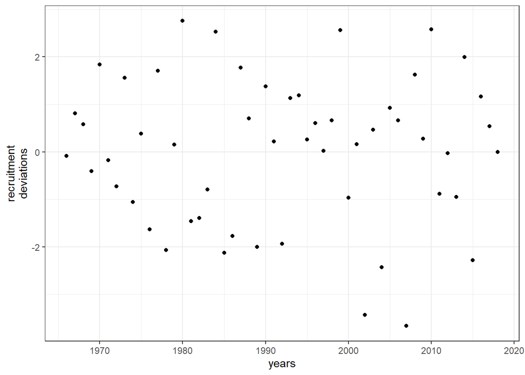

```r
df.plot <- data.frame(R = as.numeric(df$parms$Rin), years = df$years)

ggplot(df.plot, aes(x = years, y = R))+geom_point()+theme_bw()+scale_y_continuous('recruitment\ndeviations')
```

# Run the operating model

We can then use the data frame (df) to run an operating model by the parameters specified previously. The function returns a list with a range of different values

```r
#
sim.data <- run.agebased.true.catch(df)


names(sim.data)
```

```
##  [1] "N.save"                "SSB"
##  [3] "N.save.age"            "R.save"
##  [5] "V.save"                "SSB.all"
##  [7] "Catch.save.age"        "CatchN.save.age"
##  [9] "Catch"                 "Catch.age"
## [11] "Catch.quota"           "Catch.quota.N"
## [13] "Fout"                  "age_comps_OM"
## [15] "age_catch"             "SSB_0"
## [17] "N0"                    "SSB.weight"
## [19] "survey.true"           "Z"
## [21] "survey"                "age_comps_surv"
## [23] "age_comps_country"     "age_comps_catch_space"
## [25] "Fseason"               "Fsel"
## [27] "Ninit"                 "SSB0"
```

We can for instance plot the spawning stock biomass (per country) and the total catch

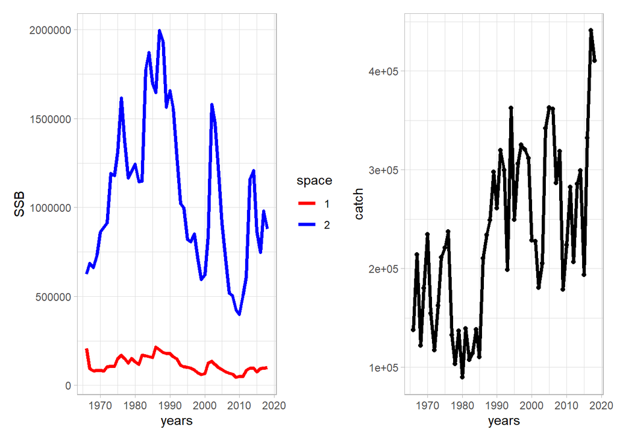

```r
ssb <- as.data.frame(sim.data$SSB)
ssb$years <- df$years

ssb <-  melt(ssb, measure.vars = 1:df$nspace,
             id.vars = 'years',
             variable.name = 'space',
             value.name = 'SSB')

ssbplot  <- ggplot(ssb, aes(x = years, y = SSB, color = space))+
  geom_line(size = 1.3)+theme_light()+
  scale_color_manual(values = c('red','blue'))

catch <- data.frame(years = df$years, catch = sim.data$Catch)


catchplot  <- ggplot(catch, aes(x = years, y = catch))+
  geom_line(size = 1.3, color = 'black')+geom_point()+theme_light()

ssbplot+catchplot
```

Or look at the dimensions of some of the simulated data (e.g., space, time, age)

```r
dim(sim.data$N.save.age)
```

```
## [1] 21 54  2  4
```

```r
dimnames(sim.data$N.save.age)
```

```
## $age
##  [1] "0"  "1"  "2"  "3"  "4"  "5"  "6"  "7"  "8"  "9"  "10" "11" "12" "13"
## [15] "14" "15" "16" "17" "18" "19" "20"
##
## $year
##  [1] "1966" "1967" "1968" "1969" "1970" "1971" "1972" "1973" "1974" "1975"
## [11] "1976" "1977" "1978" "1979" "1980" "1981" "1982" "1983" "1984" "1985"
## [21] "1986" "1987" "1988" "1989" "1990" "1991" "1992" "1993" "1994" "1995"
## [31] "1996" "1997" "1998" "1999" "2000" "2001" "2002" "2003" "2004" "2005"
## [41] "2006" "2007" "2008" "2009" "2010" "2011" "2012" "2013" "2014" "2015"
## [51] "2016" "2017" "2018" "2019"
##
## $space
## [1] "1" "2"
##
## $season
## [1] "1" "2" "3" "4"
```

We can also simulate the operating model into the future by changing the input to the df

With the operating model setup we can use it to run a stock assessment with the estmation model

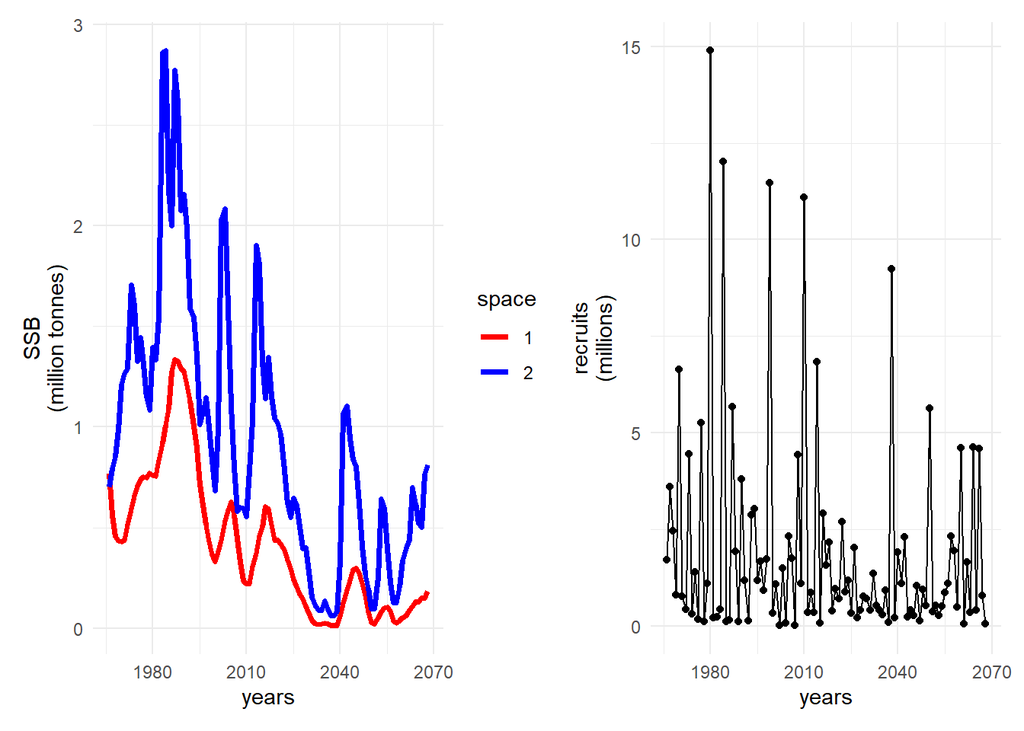

```r
df.future  <- load_data_seasons(nseason = 4,
                                nspace = 2,
                                bfuture = 1, # Bias adjustment in the future. Has to be changed based on # of simulations
                                yr_future = 50) # 50 years into the future

# Run the OM again
# As default load_data_seasons uses average historical catch for the future
sim.future <- run.agebased.true.catch(df.future)

# Plot the recruitment and spawning biomass
ssb <- as.data.frame(sim.future$SSB.all[,,3]) # Look at SSB in season 3
ssb$years <- as.numeric(rownames(ssb))

ssb.plot <- melt(ssb, measure.vars = 1:df$nspace,
             id.vars = 'years',
             variable.name = 'space',
             value.name = 'SSB')

ssbplot  <- ggplot(ssb.plot, aes(x = years, y = SSB*1e-6, color = space))+
  geom_line(size = 1.3)+theme_minimal()+scale_y_continuous('SSB\n(million tonnes)')+
  scale_color_manual(values = c('red','blue'))

R.df <- data.frame(R = rowSums(sim.future$R.save), years = df.future$years)

Rplot <- ggplot(R.df, aes(x = years, y = R*1e-6))+geom_point()+geom_line()+
theme_minimal()+scale_y_continuous('recruits\n(millions)')


ssbplot+Rplot
```

# Multiple simulations

Right now the easiest way to run multiple simulations is through a for loop. Note that the recruitment dev’s are calculated in ‘load_data_seasons’ so that call needs to be a part of the loop to get a stochastic result.

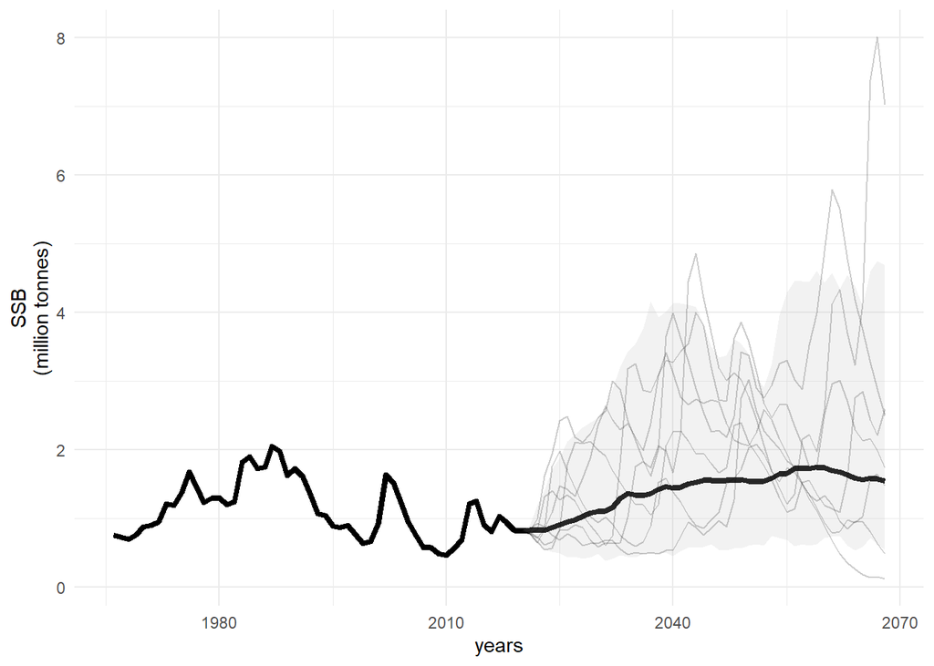

```r
n <- 100# Just run 100
seeds <- round(runif(n, min = 1, max = 1e6))

df.future  <- load_data_seasons(nseason = 1, # Use a standard model with 1 season and 1 spatial area
                                nspace = 1,
                                bfuture = 0.5,
                                yr_future = 50) # 50 years into the future

sim.tmp <- run.agebased.true.catch(df.future, seeds = seeds[1]) # Control the seed for reproducibility

SSB.save <- data.frame(n = rep(1:n, each = length(df.future$years)),
                       SSB = NA,
                       years = rep(df.future$years, n))

SSB.save[SSB.save$n == 1,]$SSB <- sim.tmp$SSB


for(i in 2:n){
  df.tmp <- load_data_seasons(nseason = 1, # Use a standard model with 1 season and 1 spatial area
                                nspace = 1,
                                bfuture = 0.5,
                                yr_future = 50) # 50 years into the future

  sim.tmp <- run.agebased.true.catch(df.tmp, seeds = seeds[i])

  SSB.save[SSB.save$n == i,]$SSB <- sim.tmp$SSB



}

# Summarize the data
idx <-  c(1,40,30,60,99, 2,15) # Plot some random runs

SSB.plot <- SSB.save %>%
  group_by(years) %>%
  summarise(SSBmean = exp(mean(log(SSB))),
            SSB90 = quantile(SSB, probs = 0.9),
            SSB10 = quantile(SSB, probs = 0.1)) %>%
  ggplot(aes(x = years,y = SSBmean*1e-6))+geom_line(size = 1.5)+theme_minimal()+scale_y_continuous('SSB\n(million tonnes)')+
  geom_ribbon(aes(ymin = SSB10*1e-6, ymax = SSB90*1e-6), fill = alpha('gray', alpha = 0.2))+
  geom_line(data = SSB.save[SSB.save$n %in% idx,],aes(y= SSB*1e-6, group = as.factor(n)),
            color =alpha('black',alpha = 0.2))+
  theme(legend.position = 'none')

SSB.plot
```

```r
# # Plot 10 individual lines
# SSBall <- ggplot(SSB.save[], aes(x = years, y = SSB*1e-6, color = as.factor(n)))+geom_line()+theme_minimal()+
#   theme(legend.position = 'none')
#
# SSB.plot+SSBall
```

# Estimation model

The second model in the MSE is the estimation model, which is a copy of the current Pacific hake assessment model, but rewritten in TMB compared to SS3.

```r
# Files that needs to be added to the package
source('R/getParameters_ss.R')
source('R/load_data_ss.R')
source('R/getUncertainty.R')

# First load the estimation model (also figure out how to make this baseline in the model)
compile("src/runHakeassessment.cpp")
```

```
## [1] 0
```

```r
dyn.load(dynlib("src/runHakeassessment"))

# For comparison load the stock synthesis model (this is the 2018 veriosn)
mod <- SS_output('inst/extdata/SS32018/', printstats=FALSE, verbose = FALSE) # Use R4SS to load
```

```
## Some stats skipped because the .par file not found:
##
```

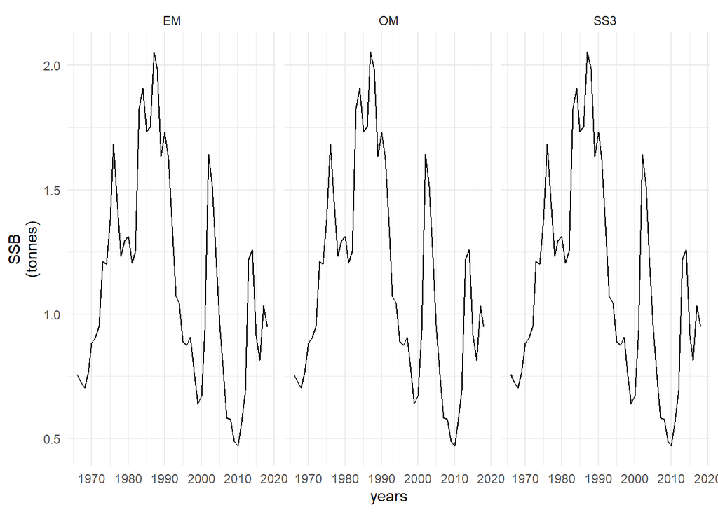

```r
df.OM <- load_data_seasons(nseason = 1, nspace = 1) # Compare it with a simple OM (1 area, 1 season)
sim.data <- run.agebased.true.catch(df.OM) # Run the OM

parms.ss <- getParameters_ss(mod) # Get the parameters to be estimated in TMB form
df <- load_data_ss(mod)

obj <-MakeADFun(df,parms.ss,DLL="runHakeassessment", silent = TRUE)

# Look at the data before fitting the model
reps <- obj$report()

# Create a data frame of spawning biomass
SSB.ss3 <- mod$derived_quants$Value[grep('SSB_1966', mod$derived_quants$Label):grep('SSB_2018', mod$derived_quants$Label)]

df.plot <- data.frame(SSB = c(reps$SSB, sim.data$SSB, SSB.ss3*0.5),
                      years = rep(df$years, 3),
                      model = rep(c('EM','OM','SS3')))



ggplot(df.plot, aes(x = years, y = SSB*1e-6))+geom_line()+theme_minimal()+facet_wrap(~model, ncol = 3)+
  scale_y_continuous('SSB\n(tonnes)')
```

The plots are virtually identical, when running them with the same parameter inputs. Let’s try to fit the TMB model to 1) the real data, and 2) to the operating model

```r
# First specify the parameter bounds
lower <- obj$par-Inf
upper <- obj$par+Inf

# Some specific bounds to help the model converge
lower[names(lower) == 'F0'] <- 0.001
upper[names(upper) == 'PSEL'] <- 9
upper[names(upper) == 'logh'] <- log(0.999)
upper[names(upper) == 'F0'] <- 2
upper[names(upper) == 'psel_fish'] <- 3
#upper[names(upper) == 'logphi_catch'] <- log(1)
lower[names(lower) == 'psel_fish'] <- 0.0001



system.time(opt<-nlminb(obj$par,obj$fn,obj$gr,lower=lower,upper=upper, # First find the MLE of the parameters
                        control = list(iter.max = 1e6,
                                       eval.max = 1e6))) #
```

```
##    user  system elapsed
##    2.35    0.00    2.36
```

```r
system.time(rep<-sdreport(obj)) # Calculate the hessian
```

```
##    user  system elapsed
##    8.02    0.05    8.19
```

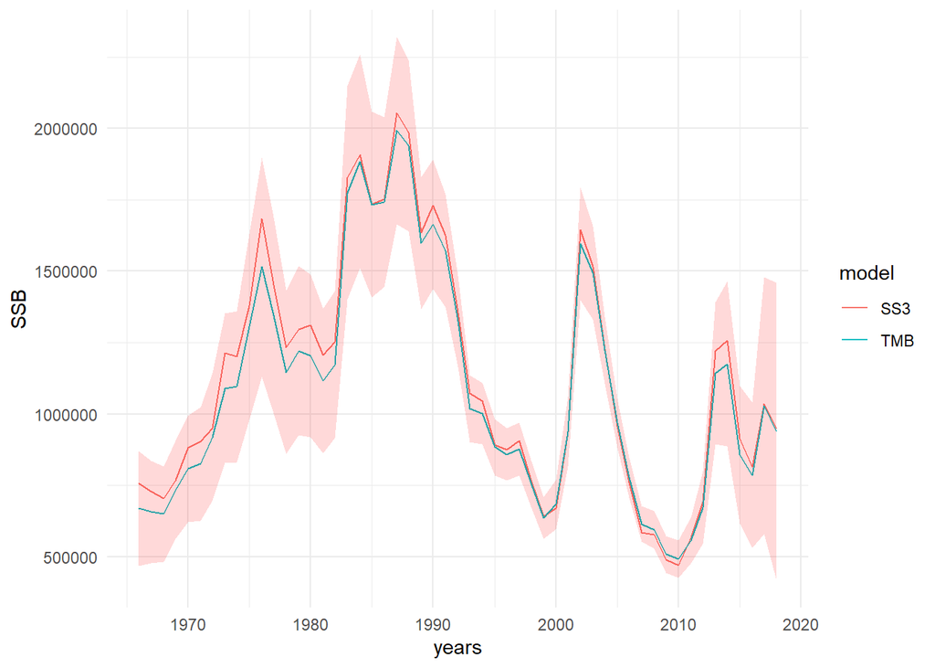

```r
sdrep <- summary(rep) # Summary report of parameters and uncertainty
rep.values<-rownames(sdrep)

df$nyear <- length(df$years) # Add some values here for plotting
df$year <- df$years

SSB <- getUncertainty('SSB',df, sdrep) # Get the uncertainty estimates
SSB$model <- 'TMB' #


df.plot <- data.frame(SSB = c(SSB$value, SSB.ss3*0.5),
                      SEmin = c(SSB$min, rep(NA, df$nyear)),
                      SEmax = c(SSB$max, rep(NA, df$nyear)),
                      years = rep(df$years, 2),
                      model = rep(c('TMB','SS3'), each = df$nyear))


# Plot the fitted model vs the SS3 model
ggplot(df.plot, aes(x = years, y = SSB, color = model))+geom_line()+theme_minimal()+
  geom_ribbon(data = df.plot, aes(ymin = SEmin, ymax = SEmax), fill = alpha('red', alpha = 0.15),
              linetype = 0, show.legend = FALSE)
```

Second we can fit the model to the operating model for a simulation analysis. Turning the OM into a TMB object is done using the function ‘create_TMB_data’ which takes input ‘sim.data’ (the operating model) and ‘df’ (the operating model parameters)

```r
df.sim <- create_TMB_data(sim.data, df.OM ) # prepare the data input from TMB based on the operating model
parms.sim <- df.OM$parms # Take the parameter input also used in the OM for initial parameters

# Add fishing mortality and recruitment to estimated parameters
F0 <- rowSums(sim.data$Fout) # Fishing mortality is calculated internally in the OM
Rdev <- parms.sim$Rin[1:(length(parms.sim$Rin)-1)] # We can't estimate the recruitment in the last year


parms.sim$F0 <- F0#rowSums(sim.data$Fsave, na.rm = TRUE)
parms.sim$Rin <- Rdev#parms.new$Rin[1:(length(parms.new$Rin)-1)]


obj.OM <- MakeADFun(df.sim,parms.sim,DLL="runHakeassessment", silent = TRUE) # Run the assessment
```

This leads to the following fit

```
##    user  system elapsed
##    2.27    0.00    2.26
```

```
##    user  system elapsed
##    7.67    0.04    7.77
```

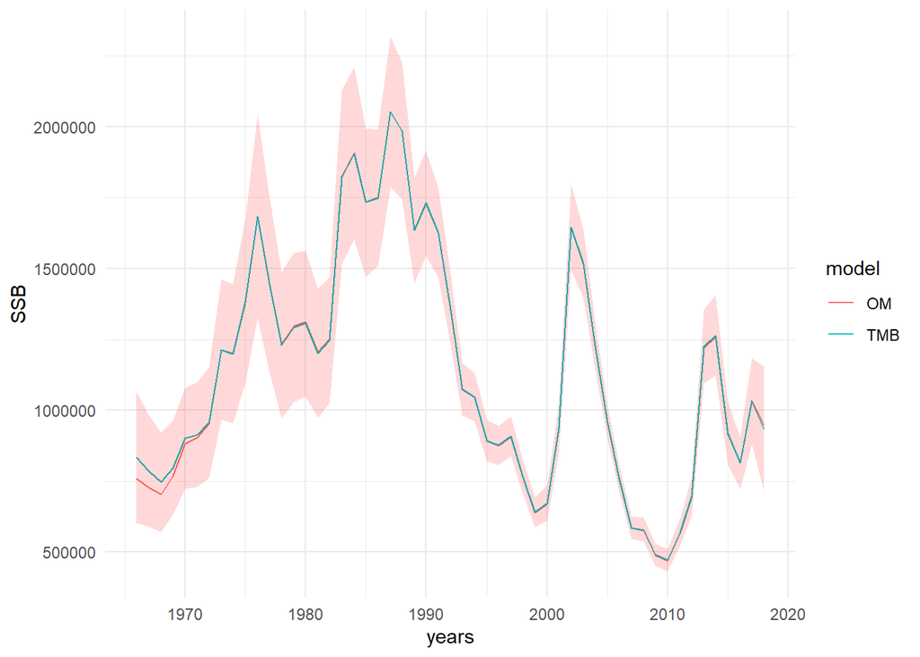

Pretty good fit - but the models are also identical.

# Look at the non timevarying parameters

Not sure why SSB is so close, but R0 seems to be so far away?

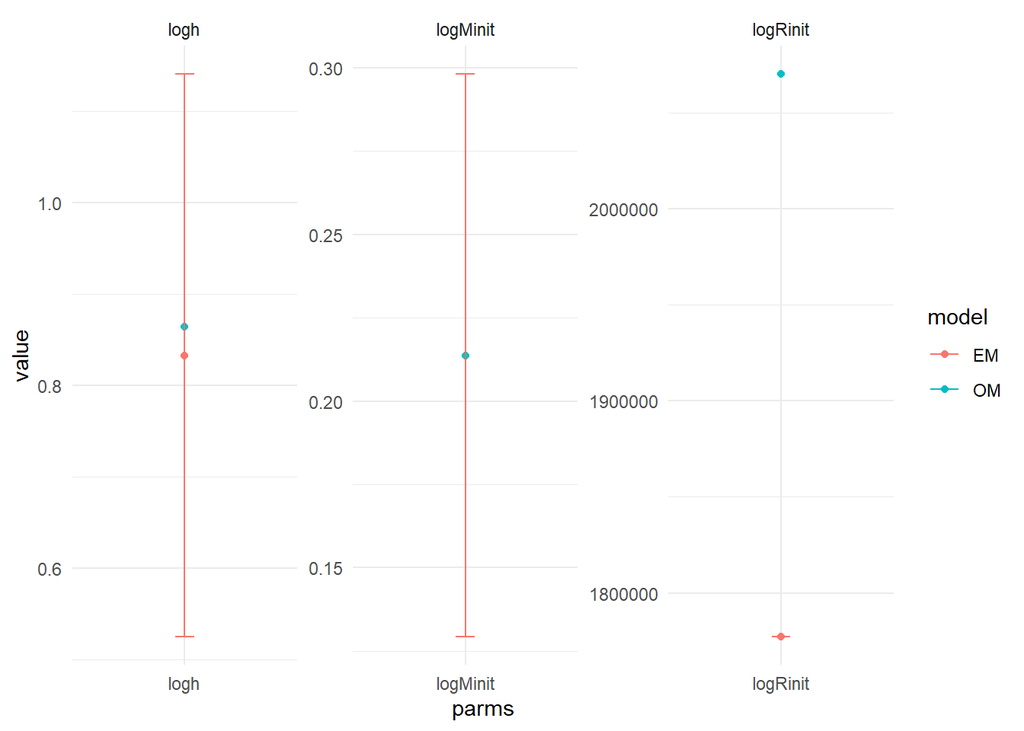

```r
idx <- 1:3 # Which parameters to plot

df.parms <- data.frame(parms = rep(rep.values[idx],2),
                       value = exp(c(sdrep[idx,1], as.numeric(parms.sim[idx]))),
                       SEMin = c(exp(sdrep[idx,1])-2*sdrep[idx,2], rep(NA, length(idx))),
                       SEMax = c(exp(sdrep[idx,1])+2*sdrep[idx,2], rep(NA, length(idx))),
                       model = rep(c('EM','OM'), each = length(idx))
)

ggplot(df.parms, aes(x = parms, y = value, color = model))+geom_point()+
  facet_wrap(~parms, scales = 'free')+geom_errorbar(aes(ymin = SEMin, ymax = SEMax), width = 0.1)+theme_minimal()
```

# Run the models combined as an MSE

Now that we know the basic structure of the code, we can prepare a range of MSE simulations. The MSEs run from the function ‘run_multiple_MSEs’ which takes input ‘simyears’ which is the number of years to simulate, and ‘df’ which is the data frame that is used to initialize the operating model. There are furthermore a range of input parameters that can be changed (with defaults), such as the movement parameters, seeds, and type of TAC .To run several MSE’s one needs to loop over the function.

```
## All parameters are identifiable
```

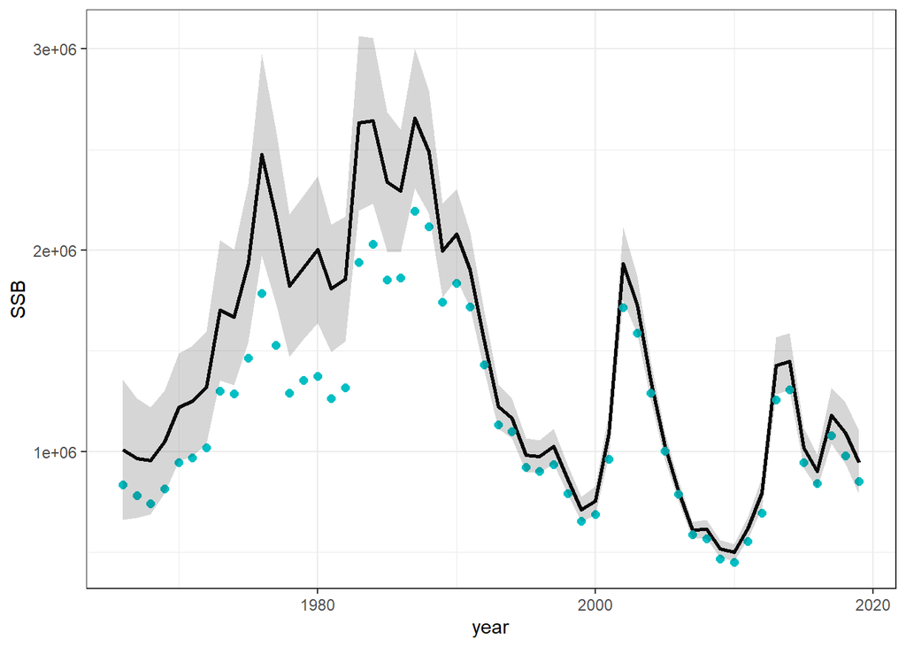

```
## Time difference of 14.81041 secs
```

```r
simyears <- 2 # run 2 yrs to make it quick

df <- load_data_seasons(nseason = 4, nspace = 2, nsurvey = 1) # This one has a survey every year

tmp <- run_multiple_MSEs(simyears = simyears,
                         seeds = 123,
                         TAC = 1, # Options are TAC 1) HCR, 2) historical, 3) realized
                         df = df)
```

Note that the run_multiple_MSEs summarizes the data, so to get different output, one would have to manipulate the function. It is pretty condensed right now to ensure that the save files don’t explode in size. Currently, the operating model is being re-run every year in the simulation, which is pretty inefficient (probably adds about 30 secs to each MSE run). Needs to be fixed. The function plots the fit to the spawning biomass in the final year including the uncertainty in estimation.

An example of a full MSE loop is printed below

```r
ls.save <- list()
ls.converge <- matrix(0, nruns)


for (i in 1:nruns){
  tmp <- run_multiple_MSEs(simyears = simyears,
                           seeds = seeds[i],
                           TAC = 1, df = df, cincrease = 0, mincrease = 0)
  print(i)

  if(is.list(tmp)){
    ls.save[[i]] <-tmp
    ls.converge[i] <- 1
  }else{
    ls.save[[i]] <- NA
    ls.converge[i] <- 0
  }


}
```